# 地方区分データの可視化

7地方区分の例

[岩田真一郎](https://shinichiro-iwata.github.io/)（ [神奈川大学経済学部](https://www.econ.kanagawa-u.ac.jp/)）

2022-08-16作成，2025-03-01改訂

# 1 目的

日本全体ではなく，一部の地方を示す．

- `NipponMap`から一部の地方を切り抜く．
- ここでは，地域区分として7地方区分（北海道地方，東北地方，関東地方，中部地方，近畿地方，中国・四国地方，九州地方）を考える．

パッケージ：`sf`，`tidyverse`，`NipponMap`

```r
library(sf)
library(tidyverse)
library(NipponMap)
```

# 2 関東地方の可視化

**シェープファイル**

作業フォルダに`jpn.shp`などが含まれる`shapes`と示されるフォルダがあることを前提とする．

- オブジェクトを`Nippon_map`とし，`read_sf()`でデータを読込．
  - シェープファイルを作業フォルダに移すのが面倒だと思う場合は，`Nippon_map<-`以降のコマンドを`read_sf(system.file("shapes/jpn.shp"), package="NipponMap")`にしても可能．この場合，移す作業は必要ない．
- `head()`を用いて上から6行を表示．
  - `region`列に地方区分が示される．`Nipponmap`は8地方区分．

```r
Nippon_map<-
  read_sf("shapes/jpn.shp", crs="WGS84")

Nippon_map %>%
  head()
```

| SP_ID | jiscode | name | population | region | geometry |
| --- | --- | --- | --- | --- | --- |
| 1 | 01 | Hokkaido | 5506419 | Hokkaido | MULTIPOLYGON (((139.7707 42… |
| 2 | 02 | Aomori | 1373339 | Tohoku | MULTIPOLYGON (((140.8727 40… |
| 3 | 03 | Iwate | 1330147 | Tohoku | MULTIPOLYGON (((140.7862 39… |
| 4 | 04 | Miyagi | 2348165 | Tohoku | MULTIPOLYGON (((140.2802 38… |
| 5 | 05 | Akita | 1085997 | Tohoku | MULTIPOLYGON (((140.7895 39… |
| 6 | 06 | Yamagata | 1168924 | Tohoku | MULTIPOLYGON (((140.2802 38… |

**関東地方選抜**

日本地図（`Nippon_map`）から関東地方（`region=="Kanto"`）を選抜． - 選抜・可視する方法は2つ．`filter()`を用いて，日本地図から関東地方だけを選抜したオブジェクトをつくり，それを可視する方法と，可視する際に`subset()`を用いて関東地方だけを選抜するように条件付けする方法．

**関東地方の可視化1**

- `filter()`を用いた場合
  - 関東地方を選抜したオブジェクト`Kanto_map`を作成．

```r
Nippon_map %>%
  filter(region=="Kanto") ->
  Kanto_map
```

- 選抜した関東地方を可視化．

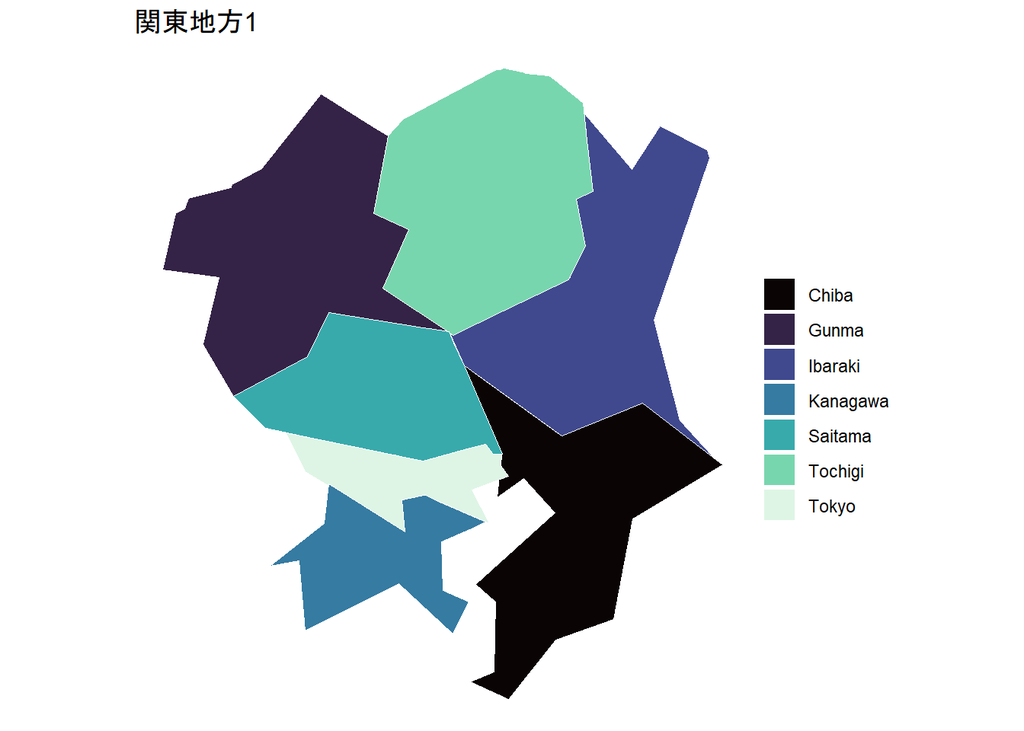

```r
ggplot()+
  geom_sf(data=Kanto_map,
          aes(fill=name), color="white")+
  scale_fill_viridis_d(option="G")+
  labs(fill="")+
  ggtitle("関東地方1")+
  theme_void()
```

**関東地方の可視化2**

- `subset()`を用いた場合
  - 関東地方と条件付けし，可視化．

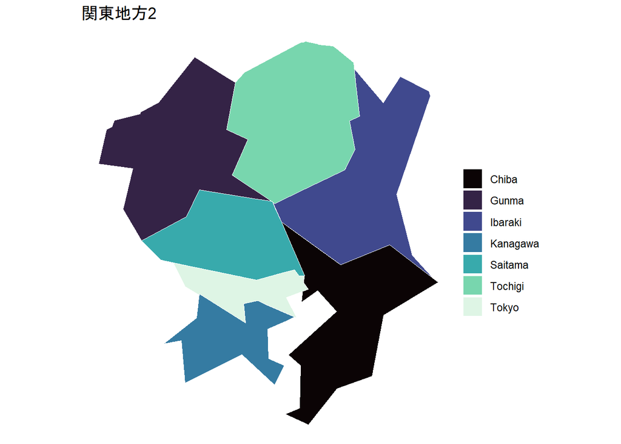

```r
ggplot()+
  geom_sf(data=subset(Nippon_map, region=="Kanto"),
          aes(fill=name), color="white")+
  scale_fill_viridis_d(option="G")+
  labs(fill="")+
  ggtitle("関東地方2")+
  theme_void()
```

**重心の計算**

凡例ではなく，地図内に地名を記入するための準備．

- 地図上に記入する場合は，記入したい位置の経度・緯度（座標）を示す必要がある．
  - ここでは，各都道府県の[重心](https://ja.wikipedia.org/wiki/%E9%87%8D%E5%BF%83)（`centroid`）に描写．[^1]
  - 都道府県のジオメトリ（ポリゴンデータ）から重心（ポイントデータ）の経度・緯度を計算する方法は以下の通り．
    - `st_centroid()`：`geometry`列の重心計算．`centroid`とする．
    - `st_coordinates()`：作成した`centroid`から経度・緯度を取り出す．`x`は経度（横軸），`y`は緯度（縦軸）．
    - `[, 1]`：`1`列目（`x`）だけを抽出．
    - `[, 2]`：`2`列目（`y`）だけを抽出．
- `head()`を用いて上から6行を表示．
  - `centroid`（重心），`x`（経度），`y`（緯度）の各列が作成されていることを確認．

```r
Kanto_map %>%
  mutate(centroid=st_centroid(geometry),
       x=st_coordinates(centroid)[, 1],
       y=st_coordinates(centroid)[, 2]) ->
  Kanto_map

Kanto_map %>%
  head()
```

| SP_ID | jiscode | name | population | region | geometry | centroid | x | y |
| --- | --- | --- | --- | --- | --- | --- | --- | --- |
| 8 | 08 | Ibaraki | 2969770 | Kanto | MULTIPOLYGON (((139.7322 36… | POINT (140.3258 36.33359) | 140.3258 | 36.33358 |
| 9 | 09 | Tochigi | 2007683 | Kanto | MULTIPOLYGON (((139.4263 36… | POINT (139.8236 36.68927) | 139.8236 | 36.68927 |
| 10 | 10 | Gunma | 2008068 | Kanto | MULTIPOLYGON (((139.3836 36… | POINT (138.9814 36.51011) | 138.9814 | 36.51011 |
| 11 | 11 | Saitama | 7194556 | Kanto | MULTIPOLYGON (((139.5503 36… | POINT (139.3505 35.99403) | 139.3505 | 35.99403 |
| 12 | 12 | Chiba | 6216289 | Kanto | MULTIPOLYGON (((139.8892 35… | POINT (140.2128 35.53531) | 140.2128 | 35.53531 |
| 13 | 13 | Tokyo | 13159388 | Kanto | MULTIPOLYGON (((139.8562 35… | POINT (139.4482 35.69422) | 139.4482 | 35.69422 |

**都道府県名の可視化**

- `geom_label()`：地図上にラベル（背景が白の文字）を作成．
  - `aes()`に示したい位置（上で作成した重心を利用），示したい内容（`label`）を示す．
  - 文字のサイズ（`size`）を指示．

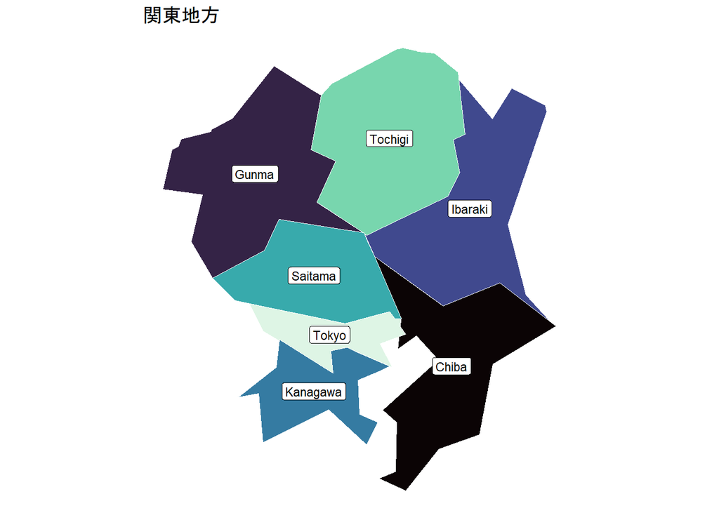

```r
ggplot()+
  geom_sf(data=Kanto_map,
          aes(fill=name), color="white")+
  scale_fill_viridis_d(option="G")+
  geom_label(data=Kanto_map,
             aes(x=x, y=y, label=name),
             size=3)+
  ggtitle("関東地方")+
  theme_void()+
  theme(legend.position="none")
```

**人口分布**

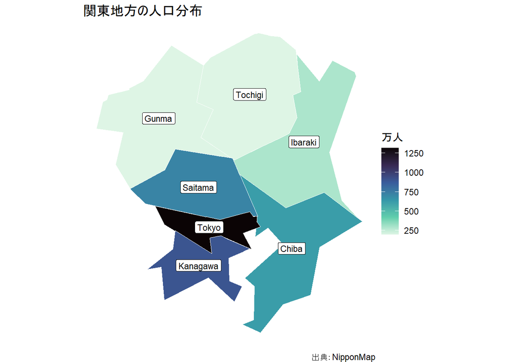

```r
ggplot()+
  geom_sf(data=Kanto_map,
          aes(fill=population/10000), color="white")+
  scale_fill_viridis_c(option="G", direction=-1)+
  geom_label(data=Kanto_map,
             aes(x=x, y=y, label=name),
             size=3)+
  labs(fill="万人", x="", y="",
       caption="出典：NipponMap")+
  ggtitle("関東地方の人口分布")+
  theme_void()
```

# 3 応用

## 3.1 その他の地方の可視化

その他の地方の地図も作成（コードは繰り返しのため一部のみ表記）．

**北海道地方，東北地方**

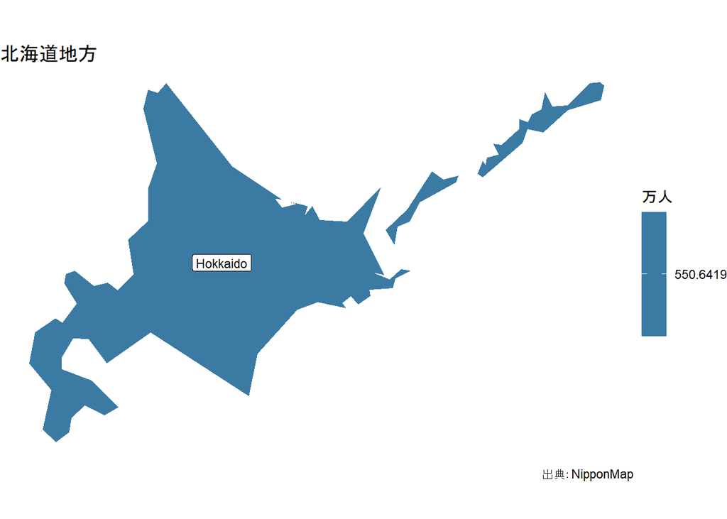

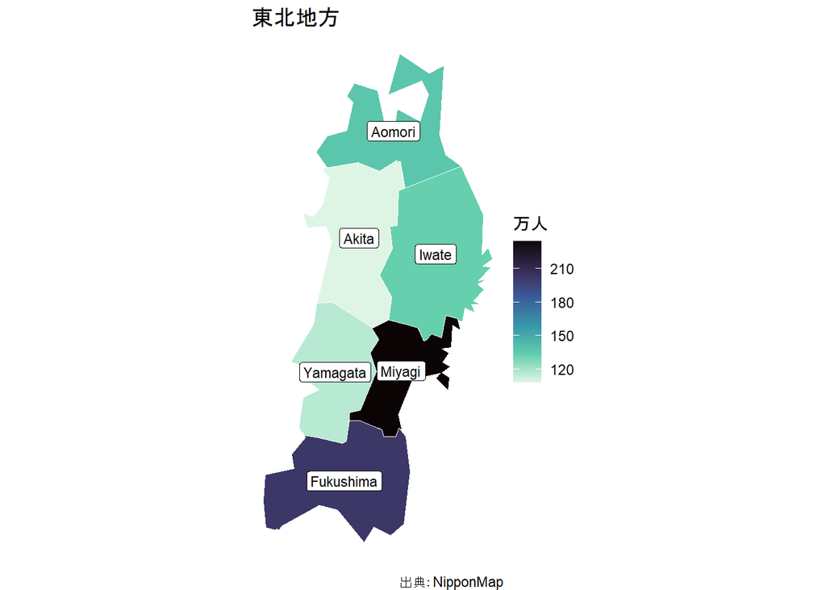

**中部地方**

富山県と石川県のラベルが重なる．

- `geom_label_repel()`を利用して，これを回避．
  - `library(ggrepel)`を呼び出す．必要に応じてパッケージをインストール（`install.packages("ggrepel")`）．

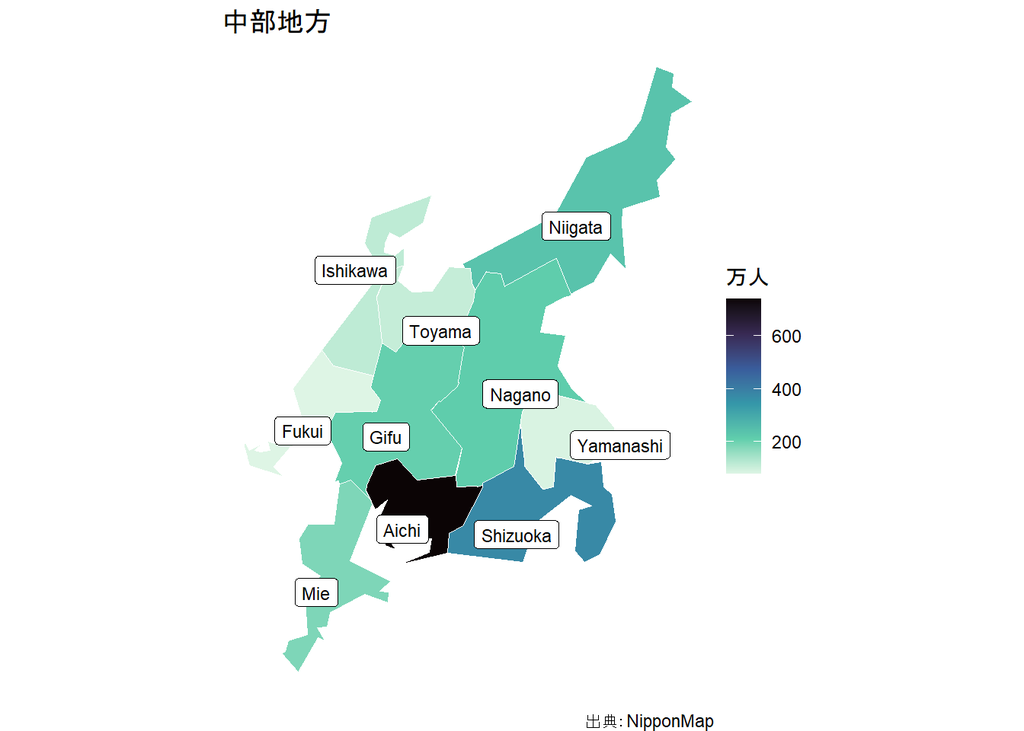

```r
#ラベルの重なりを避けるため
library(ggrepel)

#人口分布の可視化
ggplot()+
  geom_sf(data=Chubu_map,
          aes(fill=population/10000), color="white")+
  scale_fill_viridis_c(option="G", direction=-1)+
  geom_label_repel(data=Chubu_map,
             aes(x=x, y=y, label=name),
            size=3)+
  labs(fill="万人", x="", y="",
       caption="出典：NipponMap")+
  ggtitle("中部地方")+
  theme_void()
```

**近畿地方**

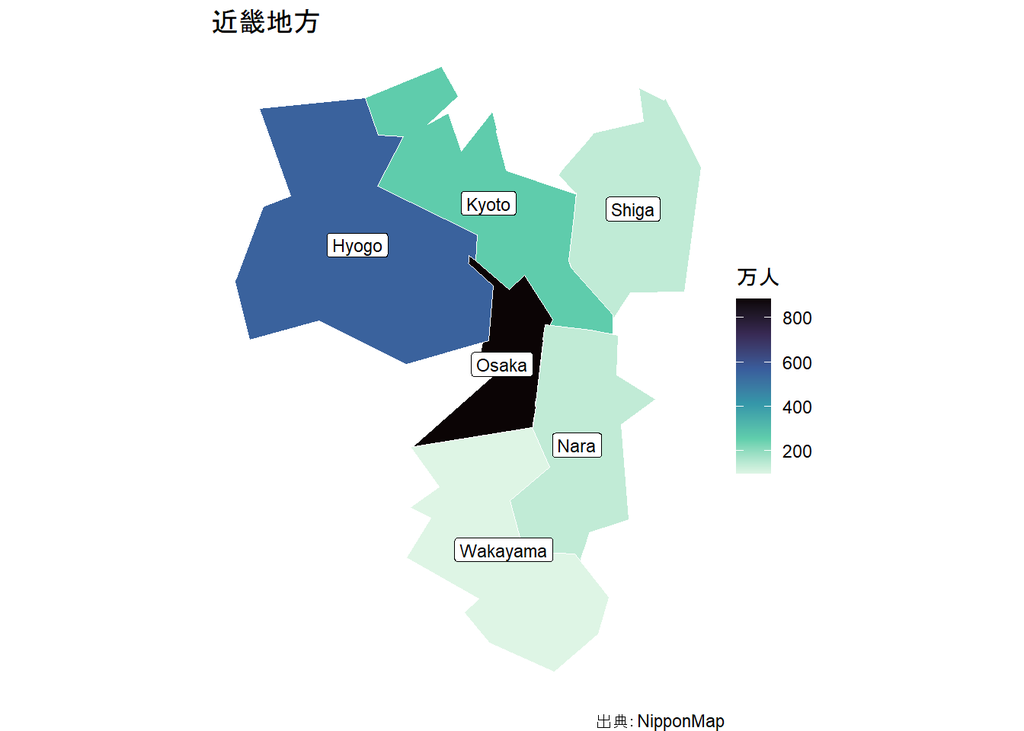

**中国・四国地方**

`NipponMap`では中国地方と四国地方が分かれている．

- 切り抜く際に，中国地方だけではなく，四国地方も切り抜く．
  - `|`は「または」を意味する論理記号．

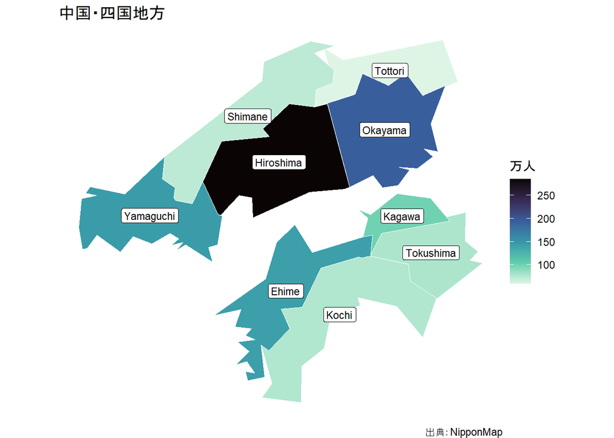

```r
#中国・四国地方の地図
Nippon_map %>%
  filter(region=="Chugoku" | region=="Shikoku") ->
  Chugoku_map

#人口分布の可視化
ggplot()+
  geom_sf(data=Chugoku_map,
          aes(fill=population/10000), color="white")+
  geom_label(data=Chugoku_map,
             aes(x=x, y=y, label=name),
             size=3)+
  scale_fill_viridis_c(option="G", direction=-1)+
  labs(fill="万人", x="", y="",
       caption="出典：NipponMap")+
  ggtitle("中国・四国地方")+
  theme_void()
```

**九州地方**

沖縄県が九州から南西方向に離れているため，沖縄県のジオメトリ（ポリゴン）を移動．

- 移動方法の詳細は[ジオメトリの移動による日本地図の可視化](https://shinichiro-iwata.github.io/geospatial-data-visualization/pld3-visualization.html)参照．

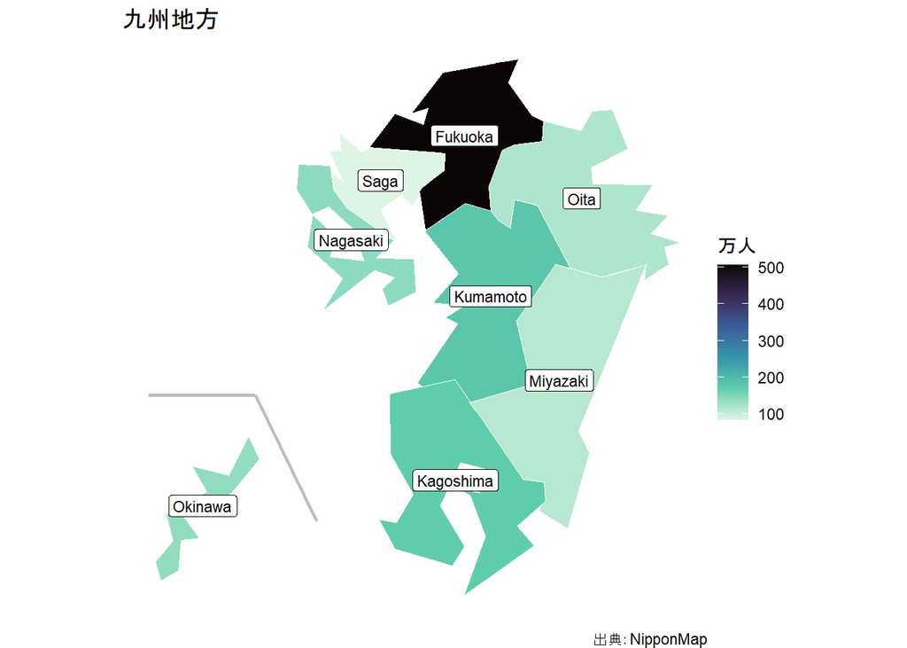

```r
#九州地方地図
Nippon_map %>%
  filter(region=="Kyushu / Okinawa") ->
  Kyushu_map

#沖縄のジオメトリの変更
Kyushu_map <- Kyushu_map %>%
  mutate(geometry=replace(
    geometry, SP_ID==47,
    geometry[SP_ID==47]+c(1, 5)))

#重心の経度・緯度の作成
Kyushu_map %>%
  mutate(centroid=st_centroid(geometry),
       x=st_coordinates(centroid)[, 1],
       y=st_coordinates(centroid)[, 2]) ->
  Kyushu_map

#人口分布の可視化
ggplot()+
  geom_sf(data=Kyushu_map,
          aes(fill=population/10000), color="white")+
  geom_label(data=Kyushu_map,
             aes(x=x, y=y, label=name),
             size=3)+
  scale_fill_viridis_c(option="G", direction=-1)+
  annotate("segment", x=128.6, xend=129.3,
           y=32.1, yend=32.1,
           color="gray", linewidth=1)+
  annotate("segment", x=129.3, xend=129.7,
           y=32.1, yend=31.4,
           color="gray", linewidth=1)+
  labs(fill="万人", x="", y="",
       caption="出典：NipponMap")+
  ggtitle("九州地方")+
  theme_void()
```

**参考ウェブサイト**

- [Rでポリゴン（面）へのラベル付け](https://note.com/misaki_blog/n/na99093ad2376)（アクセス日：2025-03-01）

**Rによる地理空間データの可視化**

- チュートリアル[ホーム](https://shinichiro-iwata.github.io/geospatial-data-visualization/)
[^1]: [Rでポリゴン（面）へのラベル付け](https://note.com/misaki_blog/n/na99093ad2376)（アクセス日：2025-03-01）を参照（重心の抜き出し方は以前と変更されている模様のため，ここに記している`R`コードと若干異なる）